# Relatório da análise dos dados da Airbnb - desafio Seazone

Wesley Almeida Cruz

# DESCRIÇÃO DO DESAFIO

Os conjuntos de dados disponível para o desafio consiste em informações sobre anúncios e ocupação no Airbnb. Abaixo é possível notar que os dois conjuntos de dados são bastante diversos, temos colunas de dados numéricos, categóricos, de data e até mesmo uma coluna com a descrição do imóvel.

O conjunto de dados **desafio_priceav.csv** possui $354.520$ linhas e 5 colunas. Abaixo está a lista de variáveis relevantes e seus respectivos contextos no conjunto de dados:

- listing_id (identificador do anúncio)
- booked_on (quando o anúncio foi alugado, caso tenha sido)
- date (data que o imóvel foi alugado)
- price_string (preço ofertado)
- available (condição binária, 1 = imóvel alugado, 0 = imóvel desocupado)

O conjunto de dados **desafio_details.csv** possui $4.691$ linhas e 8 colunas. Abaixo está a lista de variáveis relevantes e seus respectivos contextos no conjunto de dados:

- listing_id (identificador do anúncio)
- suburb (bairros disponíveis nos dados)
- ad_name (descrição do imóvel)
- number_of_bedrooms (número de quartos no imóvel)
- number_of_bathrooms (número de banheiros no imóvel)
- star_rating (nota de 1 à 5 do anúncio)
- is_superhost (condição binária, se o anunciante é um superhost (1) ou não (0))
- number_of_reviews (número de comentários no anúncio)

Vale ressaltar que como esses dados estão atrelalados a um período de tempo, todos os *insights* e interpretações devem mencionar esse fato. O escopo do tempo da coleta dos dados foi de 30/03/2020 à 02/11/2021.

Além disso, uma variável muito interessante de mencionar é a *suburb*, ou bairro, com uma pesquisa rápida no *Google* é possível perceber que os 5 bairros mencionados nos dados são pontos turísticos de Florianópolis.

**Toda a análise, incluindo tabelas e gráficos, foi feita utilizando o software RStudio e programada com a linguagem R e todos os gráficos foram feitos utilizando o pacote ggplot2**.

**OBS: Algumas imagens possuem muitos elementos e podem demorar um pouco para renderizar no PDF, basta esperar alguns segundos que essas imagens irão aparecer**

# LEITURA DOS DADOS E PACOTES

```r
## OBS: Não adicionei acentuação de acordo com a norma da lingua portuguesa nos
## comentarios para garantir uma melhor visualizacao em qualquer computador.

# Pacotes relevantes para a analise
library(ggcorrplot)
library(gridExtra)
library(tidyverse)
library(polycor)
library(scales)

# Lendo os arquivos desafio_priceav.csv e desafio_details.csv no R
price <- read.csv("desafio_priceav.csv")
details <- read.csv("desafio_details.csv",encoding = "UTF-8")

# Retirando variaveis que não tem importancia para a analise
price <- price[,-c(1,2)]
details <- details[,-1]

# Alterando os nomes das colunas para melhor visualizacao
names(price) <- c("listing_id","booked_on","date",
                  "price_string","available")
names(details)[1] <- "listing_id"
```

# ORDENAÇÃO DOS BAIRROS POR ORDEM CRESCENTE DE LISTINGS

Para encontrar a informação necessária foi necessário agrupar os dados pelos bairros utilizando a função *group_by()* do pacote **dplyr** (chamado pelo pacote **tidyverse**) e contar o número de anúncios em cada bairro com a função *count()*.

```r
# Calculando o numero de listings por bairro
listing_bairro <- details %>%
  group_by(suburb) %>%        # Agrupando os dados por bairro
  select(listing_id) %>%      # Selecionando os ids
  count() %>%                 # Contando os ids por bairro
  arrange(n)                  # Ordenando os resultados

df1 <- listing_bairro
names(df1) <- c("Bairro","Quantidade de anúncios")
kable(df1,format = "html") %>%
  kable_styling(position = "center",latex_options = "HOLD_position")
```

| Bairro | Quantidade de anúncios |
| --- | --- |
| Centro | 278 |
| Lagoa da Conceição | 309 |
| Jurerê | 539 |
| Canasvieiras | 1177 |
| Ingleses | 2388 |

Os bairros Ingleses, Canasvieiras e Jurerê (em ordem) somam $87.5\%$ de todos os anúncios entre o período de tempo analisado.

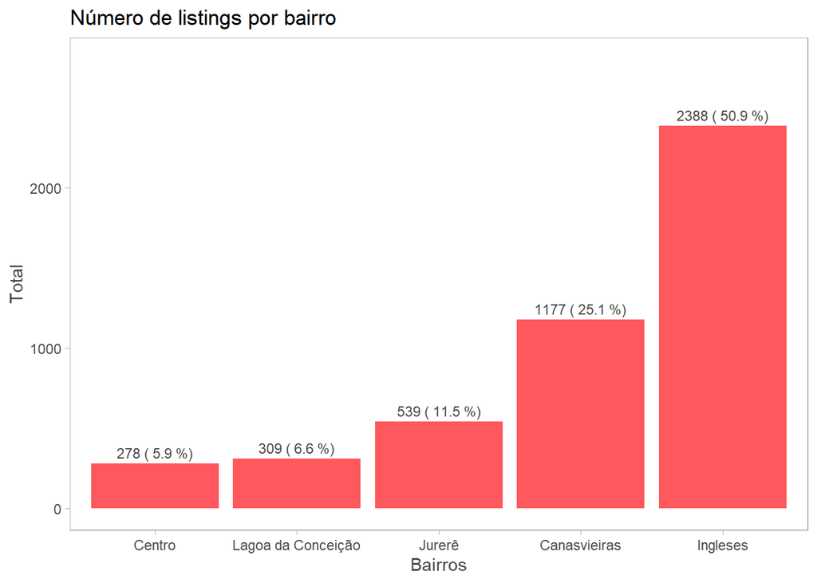

```r
# Grafico de barras com valores acima das barras do numero de listing por bairro
ggplot(listing_bairro, aes(x=reorder(suburb,n),y=n))+
  geom_col(fill="#FF585D")+
  geom_text(aes(label=paste(n,"(",round(100*n/4691,1),"%)")),
            vjust=-0.5,size=3, color="#484848",) +
  ylim(0,2800)+
  labs(x = "Bairros", y = "Total",
       title = "Número de listings por bairro")+
  theme_light()+
  theme(panel.grid = element_blank(),
        axis.title = element_text(colour = "#484848"))
```

# ORDENAÇÃO DOS BAIRROS POR ORDEM CRESCENTE DO FATURAMENTO MÉDIO DE LISTINGS

Para fazer uma ordenação dos bairros de acordo com o faturamento médio dos anúncios é necessário primeiramente juntar os conjuntos de dados, já que só metade da informação pode ser adquirida por um desses conjuntos. Podemos notar que ambos os dados dispõe da variável *listing_id*, dessa forma podemos usa-la como um conectivo entre o conjunto price e details.

O novo conjunto **price_details** é a junção de **price** e **details** e a sua dimensão é de $354.520$ linhas por 12 colunas.

```r
# Mesclando os conjuntos de dados price e details usando como conectivo a variável listing_id
price_details <- left_join(price,details, by = "listing_id")
```

Para calcular o faturamento total por bairro, foi necessário agrupar os dados por *listing_id* e *bairro*, respectivamente, e somar a variável *price_String* em cada grupo criado, isso é equivalente a somar todos o histórico de preços ofertados de um específico anúncio.

```r
# Calculando o faturamento total por bairro
faturamento_total <- price_details %>%
  group_by(listing_id,suburb) %>% # Agrupando por listing_id e bairro
  summarise_at(vars("price_string"),
               list(faturamento=sum)) # Somando os preços ofertados
```

```r
price_details$listing_id %>%
  unique() %>% length() # Número total de listings_id em price_details
```

```
## [1] 3347
```

```r
faturamento_total$listing_id %>%
  unique() %>% length() # Número total de listings_id em faturamento_total
```

```
## [1] 3347
```

O fato dos valores únicos dos *listing_ids* serem iguais para os conjuntos de dados **price_details** e **faturamento_total** prova que só existe um bairro por listing nessa amostra. Dessa forma somando todos os *listings_ids* identicos por bairro irá retornar o faturamento total daquele anúncio específico, justificando a forma que foi calculado o faturamento total por bairro.

Para encontrar o faturamento médio por bairro basta agrupar o conjunto de dados **faturamento_total** por bairro e aplicar a média nesses grupos.

```r
# Calculando o faturamento medio por bairro
faturamento_medio <- faturamento_total %>%
  group_by(suburb) %>%               # Agrupando por bairro
  summarise_at(vars("faturamento"),
               list(media=mean)) %>% # Media de faturamento por bairro
  arrange(media)                     # Ordenando as medias

df2 <- faturamento_medio
names(df2) <- c("Bairro","Faturamento médio")

kable(df2,format = "html") %>%
  kable_styling(position = "center",latex_options = "HOLD_position")
```

| Bairro | Faturamento médio |
| --- | --- |
| Centro | 21332.82 |
| Lagoa da Conceição | 27049.76 |
| Canasvieiras | 31730.54 |
| Ingleses | 36238.61 |
| Jurerê | 46657.24 |

O faturamento médio dos anúncios é maior nos bairros com um maior número de anúncios, assim, os bairros Ingleses, Canasvieiras e Jurerê somam $87.5\%$ de todos os *listings*. Porém, o bairro com a maior média não é o que possui mais anúncios (Ingleses) e sim o que compõe somente $11.5\%$ do total de anúncios, o bairro Jurerê.

Uma pesquisa breve me indicou que provavelmente o bairro Jurerê é considerado mais nobre, com uma urbanização projetada pelo arquiteto Oscar Niemeyer e considerado um empreendimento imobiliário em larga escala. Por essas e mais razões é possível justificar a média alta de preços.

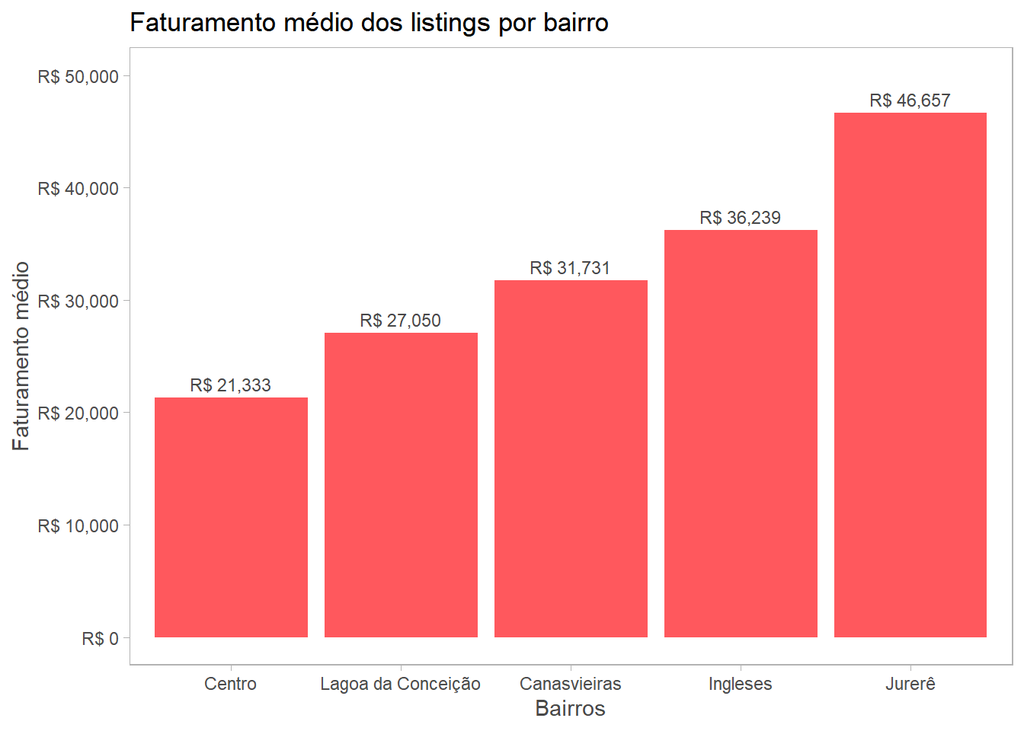

```r
# Grafico de barras com valores acima das barras do faturamento medio de listing por bairro
ggplot(faturamento_medio, aes(x=reorder(suburb,media),y=media))+
  geom_col(fill="#FF585D")+
  geom_text(aes(label=dollar(round(media),prefix = "R$ ")),
            vjust=-0.5,size=3, color="#484848")+
  scale_y_continuous(labels=dollar_format(prefix="R$ "),
                     limits=c(0,50000))+
  labs(x = "Bairros", y = "Faturamento médio",
       title = "Faturamento médio dos listings por bairro")+
  theme_light()+
  theme(panel.grid = element_blank(),
        axis.title = element_text(colour = "#484848"))
```

# EXISTEM CORRELAÇÕES ENTRE AS CARACTERÍSTICAS DE UM ANÚNCIO E SEU FATURAMENTO?

Inicialmente, eu decidi juntar **price_details** com a terceira coluna de **faturamento_total**, utilizando como conector a primeira coluna desse conjunto de dados, *listing_id*.

```r
# Mesclando os conjuntos de dados price_details e faturamento_total
price_details <- left_join(price_details,
                           faturamento_total[c(1,3)],
                           by = "listing_id")

price_details$available <- as.factor(price_details$available)
price_details$suburb <- as.factor(price_details$suburb)
price_details$is_superhost <- as.factor(price_details$is_superhost)
price_details$star_rating <- as.factor(price_details$star_rating)
```

Como existem características que podem e devem ser consideradas categóricas que serão cruzadas com variáveis numéricas, os métodos convencionais para calcular matrizes de correlação entre variáveis não funcionam.

Existe um método capaz de calcular correlações entre variáveis categóricas e numéricas, gerando uma matriz de correlações heterogênea. Porém, as variáveis categóricas devem ser ordinais, ou seja, devem ter uma ordenação natural ($0 < 1 < 2 < ...$). Todas as variáveis com exceção de *suburb* (bairro), atendem essas condições, então podemos calcular a matriz de correlação heterogênea.

A interpretacão do resultado é análoga ao método convencional: quanto maior o valor da medida mais correlacionado são as variáveis e quanto menor a medida menos as variáveis sao correlacionadas. A medida de correlação varia entre $-1$ e $1$.

De acordo com a visualização abaixo, é possível notar que as correlações mais intensas com faturamento são *price_string* ($r = 0.51$), *number_of_bathrooms* ($r = 0.31$) e *number_of_bedrooms* ($r = 0.28$). A variável *star_rating* também apresentou uma leve correlação ($r = 0.12$), mas provavelmente não é significativa.

O alto valor da correlação entre o preço do anúncio e o faturamento é esperado, pois imóveis mais valorizados geralmente também são bastante procurados. O número de banheiros e quartos também faz sentido, pois quanto maior o espaço do imóvel mais pessoas podem alugar, uma família ou um grupo de amigos por exemplo.

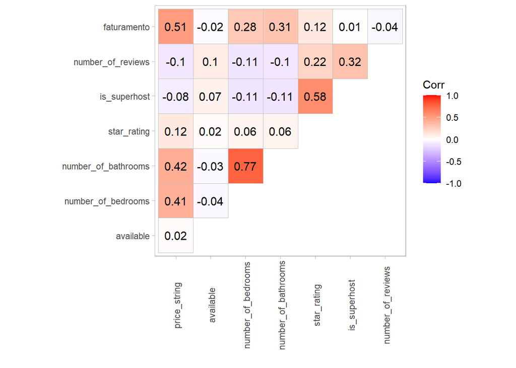

```r
correlacao <- hetcor(price_details[,c(4,5,8:13)])

# Visualizando a matriz de correlacao heterogenea de forma grafica
ggcorrplot(correlacao$correlations,
           method = "square",
           type = "upper",
           lab = T)+
  theme_light()+
labs(x = "", y = "")+
  theme(panel.grid = element_blank(),
        axis.text.x = element_text(angle = 90,vjust = 0.6))
```

Outra forma de verificar se existem possíveis correlações entre variáveis categóricas e numéricas é utilizando gráficos de *boxplots*. Se houverem diferenças significativas entre a linha mediana (linha preta) do *boxplot* entre os níveis, então provavelmente existe algum tipo de associação entre as duas variáveis.

```r
# Função que encontra valores que não pertencem em um vetor
`%notin%` <- Negate(`%in%`)

# Função para gerar boxplots entre o faturamento e variaveis categoricas
boxp <- function(var,var_n,tt){
  num <- which(names(price_details)==var)
  price_details$vari <- price_details[,num]

  price_details <- price_details %>% filter(is.na(vari) == F)

  ggplot(price_details, aes(x=as.factor(vari),y=faturamento))+
    geom_boxplot(fill="#FF585D")+
    scale_y_continuous(labels=dollar_format(prefix="R$ "))+
    labs(x = var_n, y = "Faturamento",title = tt)+
    theme_light()+
    theme(panel.grid = element_blank())
}

# Função para gerar boxplots entre o faturamento e variaveis categoricas retirando os outliers
boxp_out <- function(var,var_n,tt){
  num <- which(names(price_details)==var)
  price_details$vari <- price_details[,num]

  outliers <- boxplot(price_details$faturamento,plot = F)$out

  price_details <- price_details %>% filter(is.na(vari) == F)
  price_details <- price_details %>% filter(faturamento %notin% outliers)

  ggplot(price_details,
         aes(x=as.factor(vari),y=faturamento))+
    geom_boxplot(fill="#FF585D",outlier.shape = NA)+
    scale_y_continuous(limits = quantile(price_details$faturamento, c(0.1, 0.9)))+
    scale_y_continuous(labels=dollar_format(prefix="R$ "))+
    labs(x = var_n, y = "Faturamento",title=tt)+
    theme_light()+
    theme(panel.grid = element_blank())
}

p1_1 <- boxp(names(price_details)[5],"Disponibilidade","Com outliers")
p1_2 <- boxp(names(price_details)[6],"Bairro","Com outliers")
p1_3 <- boxp(names(price_details)[10],"Star rating","Com outliers")
p1_4 <- boxp(names(price_details)[11],"Superhost","Com outliers")
p1_5 <- boxp(names(price_details)[8],"Número de quartos","Com outliers")
p1_6 <- boxp(names(price_details)[9],"Número de banheiros","Com outliers")

p2_1 <- boxp_out(names(price_details)[5],"Disponibilidade","Sem outliers")
p2_2 <- boxp_out(names(price_details)[6],"Bairro","Sem outliers")
p2_3 <- boxp_out(names(price_details)[10],"Star rating","Sem outliers")
p2_4 <- boxp_out(names(price_details)[11],"Superhost","Sem outliers")
p2_5 <- boxp_out(names(price_details)[8],"Número de quartos","Sem outliers")
p2_6 <- boxp_out(names(price_details)[9],"Número de banheiros","Sem outliers")
```

Visualmente, as variáveis que apresentaram possíveis diferenças entre os níveis foram *suburb*, *number_of_bathrooms* e *number_of_bedrooms* e talvez a variável *star_rating*. Isso confirma a informação encontrada na matriz de correlação heterogênea. Lembrando que *suburb* não foi considerado para o cálculo da matriz de correlação porquê não é uma variável ordinal.

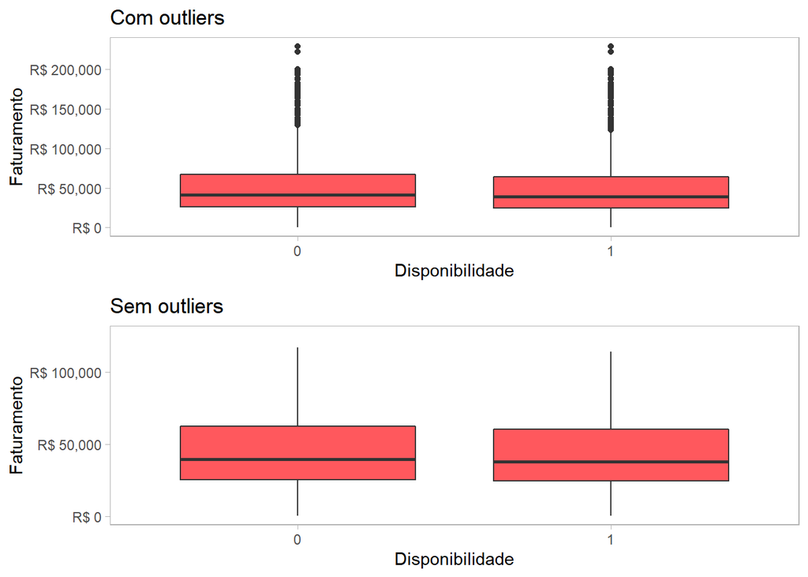

```r
grid.arrange(p1_1,p2_1,ncol=1)
```

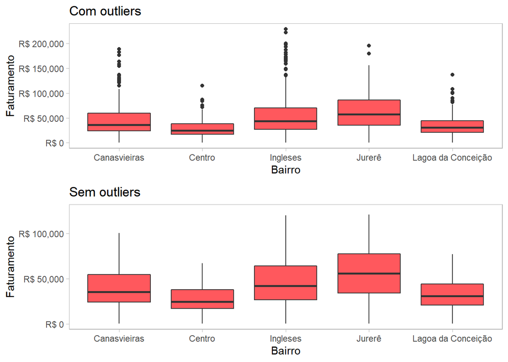

```r
grid.arrange(p1_2,p2_2,ncol=1)
```

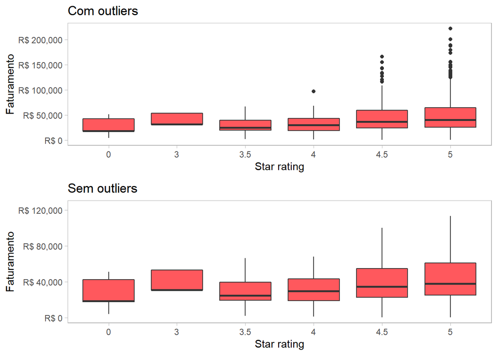

```r
grid.arrange(p1_3,p2_3,ncol=1)
```

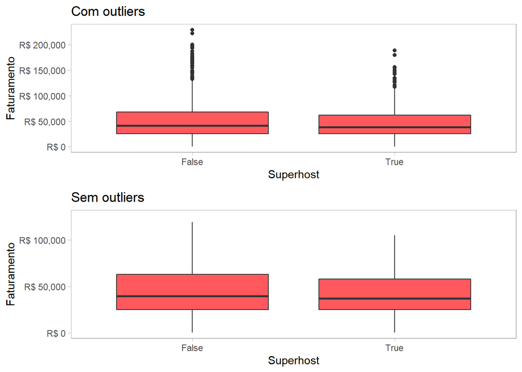

```r
grid.arrange(p1_4,p2_4,ncol=1)
```

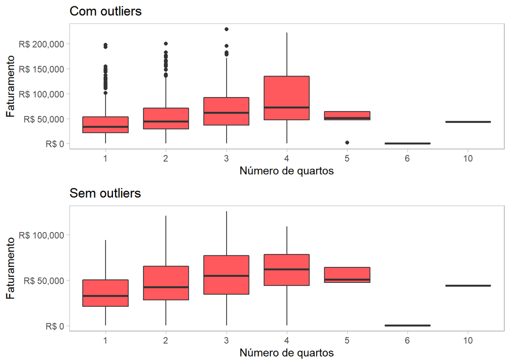

```r
grid.arrange(p1_5,p2_5,ncol=1)
```

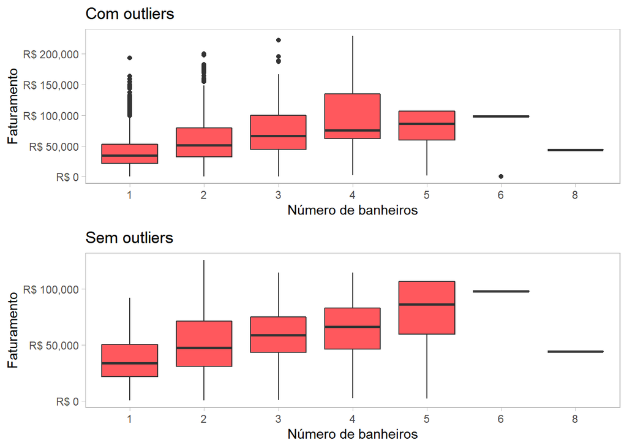

```r
grid.arrange(p1_6,p2_6,ncol=1)
```

Por outro lado, para visualizar sinais de correlação entre duas variáveis numéricas podemos mostrar em um gráfico de dispersão, se houver alguma tendência negativa ou positiva então existe a possibilidade de que as variáveis sejam correlacionadas.

```r
# Função para gerar graficos de dispersao entre o faturamento e variaveis numericas
dispersao <- function(var,var_n,tt){
  num <- which(names(price_details)==var)
  price_details$vari <- price_details[,num]

  ggplot(price_details,aes(x=vari,y=faturamento))+
    geom_point(color="#FF585D",alpha=0.3)+
    scale_y_continuous(labels=dollar_format(prefix="R$ "))+
    labs(x = var_n, y = "Faturamento",title = tt)+
    theme_light()+
    theme(panel.grid = element_blank())
}

# Função para gerar graficos de dispersao entre o faturamento e variaveis numericas
dispersao_out <- function(var,var_n,tt){
  num <- which(names(price_details)==var)
  price_details$vari <- price_details[,num]

  outliers1 <- boxplot(price_details$faturamento,plot = F)$out
  outliers2 <- boxplot(price_details$vari,plot = F)$out

  price_details <- price_details %>%
    filter(faturamento < min(outliers1) & vari < min(outliers2))

  ggplot(price_details,aes(x=vari,y=faturamento))+
    geom_point(color="#FF585D",alpha=0.3)+
    scale_y_continuous(labels=dollar_format(prefix="R$ "))+
    labs(x = var_n, y = "Faturamento",title=tt)+
    theme_light()+
    theme(panel.grid = element_blank())
}

p3_1 <- dispersao(names(price_details)[4],"Preço ofertado","Com outliers")
p3_2 <- dispersao(names(price_details)[12],"Número de reviews","Com outliers")

p4_1 <- dispersao_out(names(price_details)[4],"Preço ofertado","Sem outliers")
p4_2 <- dispersao_out(names(price_details)[12],"Número de reviews","Sem outliers")
```

Aparentemente a variável *price_string* apresenta uma tendência positiva (quanto maior o preço ofertado maior é o faturamento), porém os dados são muito concentrados devido à valores *outliers* de ambas as variaveis e uma variabilidade alta, ao retirar esses valores *outliers* dos dados essa tendência se torna levemente mais aparente. Já a variável *number_of_reviews* apresenta tendência negativa mas não se percebe uma diferença significativa ao retirar os valores *outliers*.

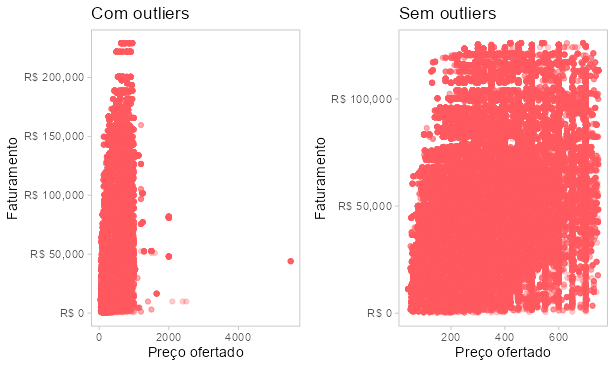

```r
# grid.arrange(p3_1,p4_1,ncol=2)
# grid.arrange(p3_2,p4_2,ncol=2)

knitr::include_graphics("img1.png")
```

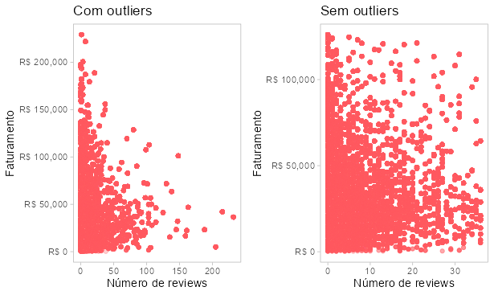

```r
knitr::include_graphics("img2.png")
```

Também achei interessante responder se o número total de anúncios se correlaciona com o faturamento, e como era de se esperar de fato há uma correlação ($r = 0.68$).

```r
# Calculando o numero total de anuncios
total_listing <- price_details %>%
  group_by(listing_id) %>%             # Agrupando por listing_id
  count()                              # Contagem por listing_id
names(total_listing)[2] <- "total_reservas"

#Mesclando o conjunto de dados price_details e total_listing com o conectivo listing_id
price_details <- left_join(price_details,total_listing, by = "listing_id")

cor(price_details$faturamento,price_details$total_reservas) # r = 0.68
```

```
## [1] 0.681535
```

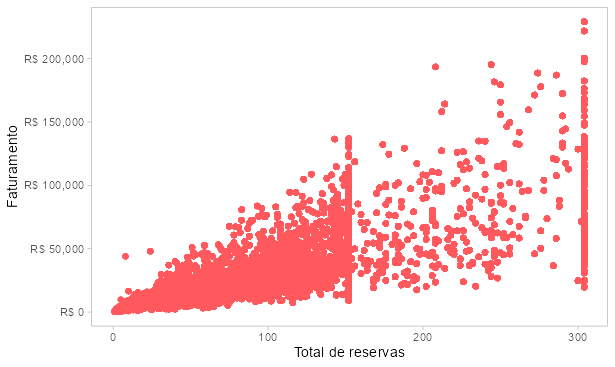

```r
#ggplot(price_details,aes(x=total_reservas,y=faturamento))+
#  geom_point(color="#FF585D")+
#  scale_y_continuous(labels=dollar_format(prefix="R$ "))+
#  labs(x = "Total de reservas", y = "Faturamento")+
#  theme_light()+
#  theme(panel.grid = element_blank())

knitr::include_graphics("img3.png")
```

Obs: Existem muitos pontos nos últimos três gráfico, dessa forma, optei por usar imagens salvas dos gráficos, pois o PDF demorava a renderizar a página com esses gráficos, os *scripts* que geram os gráficos estão comentados nos *chunks* de código.

# QUAL A ANTECENDÊNCIA MÉDIA DAS RESERVAS?

Inicialmente, devemos encontrar a diferença entre as variáveis *date* e *booked_on* do conjunto de dados **price_details**. Fazemos isso transformando as duas variáveis para o formato de data e aplicando a função *difftime()*.

```r
# Transformando booked_on e date em dados de data
price_details$booked_on <- ifelse(price_details$booked_on=="blank",
                                  NA,price_details$booked_on)
price_details$booked_on <- as.Date(price_details$booked_on)
price_details$date <- as.Date(price_details$date)

# Calculando a diferenca entre a data alugada e quando foi alugado,
# encontrando a antecedencia da reserva
price_details$date_diff <- difftime(price_details$date,
                                    price_details$booked_on,units="days")

# Criando um objeto para o vetor de antecedencia
date_diff <- price_details$date_diff
date_diff <- na.omit(date_diff)     # retirando os NAs
```

```r
df21 <- date_diff %>% as.numeric() %>% summary() %>% as.matrix() %>% as.data.frame() %>% t()
rownames(df21) <- NULL

kable(df21,format = "html") %>%
  kable_styling(position = "center",latex_options = "HOLD_position")
```

| Min. | 1st Qu. | Median | Mean | 3rd Qu. | Max. |
| --- | --- | --- | --- | --- | --- |
| 0 | 0 | 6 | 32.35171 | 34 | 7644 |

O valor da antecedência média foi de aproximadamente 32 dias, porém, ao olhar o histograma do vetor de antecedência notamos que esse valor esta muito alto, devido a alguns valores extremos, como por exemplo $7644$ dias de antecedencia, que aumentaram o valor da média que é sensível a valores *outliers*.

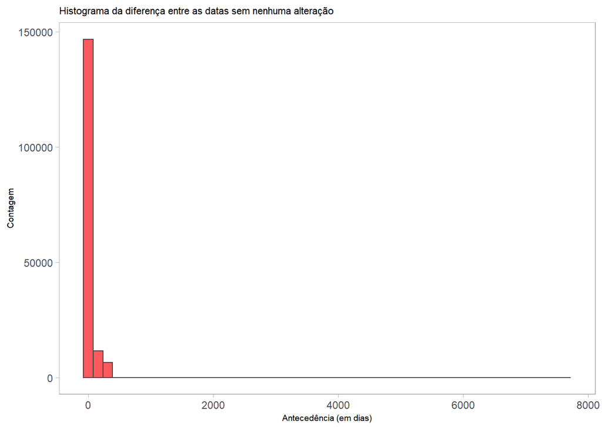

```r
ggplot()+
  geom_histogram(aes(x=date_diff),bins=50,col="#484848",fill = "#FF585D")+
  labs(x="Antecedência (em dias)", y = "Contagem",
       title="Histograma da diferença entre as datas sem nenhuma alteração")+
  theme_light()+
  theme(panel.grid = element_blank(),
        title = element_text(size=7))
```

Dessa forma, para encontrar a antecedência média corretamente seria de interesse retirar os valores *outliers*.

```r
# Encontrando os valores outliers e os removendo
outliers_diff <- boxplot(date_diff, plot = F)$out
date_diff_out <- date_diff[-which(date_diff %in% outliers_diff)]
```

Apos retirar os valores *outliers* ficamos com uma antecência média de aproximadamente 15 dias, que é um valor muito mais realista.

```r
df22 <- date_diff_out %>% as.numeric() %>% summary() %>% as.matrix() %>% as.data.frame() %>% t()
rownames(df22) <- NULL

kable(df22,format = "html") %>%
  kable_styling(position = "center",latex_options = "HOLD_position")
```

| Min. | 1st Qu. | Median | Mean | 3rd Qu. | Max. |
| --- | --- | --- | --- | --- | --- |
| 0 | 0 | 4 | 14.62166 | 22 | 85 |

É possível ver que, ao retirar os valores *outliers* a distribuição de antecedência varia entre 0 e aproximadamente 80 dias.

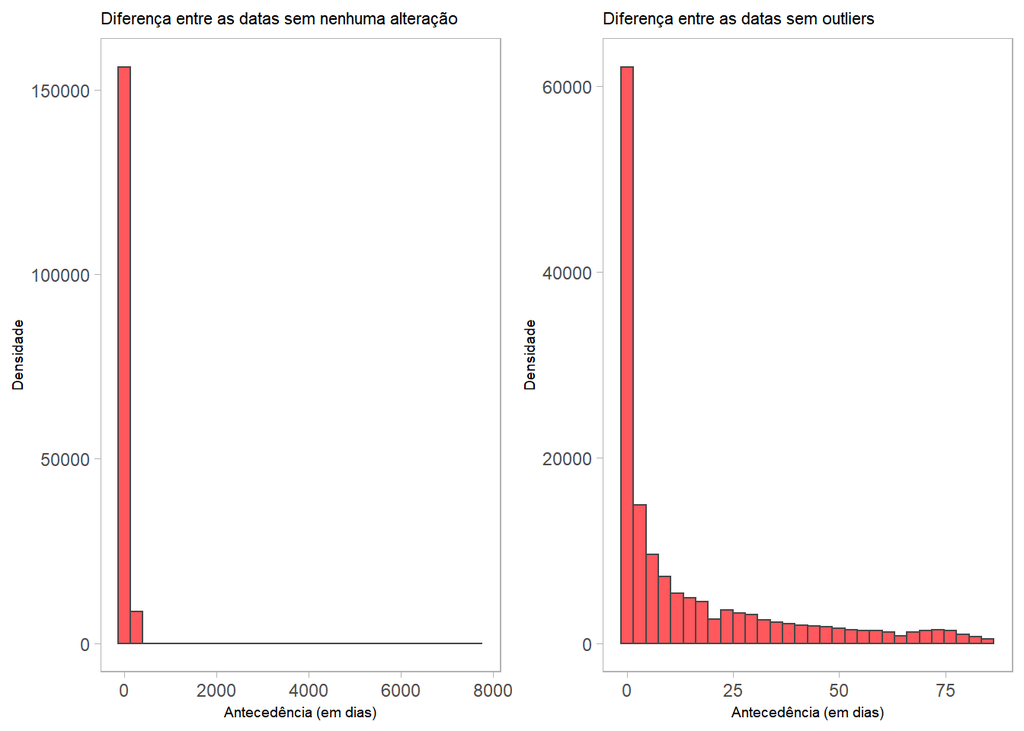

```r
p5 <- ggplot()+
  geom_histogram(aes(x=date_diff),col="#484848",fill = "#FF585D")+
  labs(x="Antecedência (em dias)", y = "Densidade",
       title="Diferença entre as datas sem nenhuma alteração")+
  theme_light()+
  theme(panel.grid = element_blank(),
        title = element_text(size=7))

p6 <- ggplot()+
  geom_histogram(aes(x=date_diff_out),col="#484848",fill = "#FF585D")+
  labs(x="Antecedência (em dias)", y = "Densidade",
       title="Diferença entre as datas sem outliers")+
  theme_light()+
  theme(panel.grid = element_blank(),
        title = element_text(size=7))

grid.arrange(p5,p6,ncol=2)
```

Vale ressaltar que as medianas ($50\%$ dos dados) foram bastante proximas, mediana de 6 dias de antecedência para os dados originais e 4 dias de antecedência para os dados sem *outliers*, a medida da mediana é mais confiável nessa situação de valores extremos, pois é uma medida robusta contra valores extremos.

## ESSE NÚMERO É MAIOR OU MENOR NOS FINAIS DE SEMANA?

Para responder essa pergunta devemos criar uma nova variável *weekday* que transforma a variável *date* em dias da semana de acordo com o dia do ano, para isso basta aplicar a função *weekdays()*. Posteriormente, foram aplicadas algumas transformações nos níveis para regionalizar a variável, por exemplo *monday* foi trocado por segunda-feira.

```r
# Criando a variavel para os dias da semana com a funcao weekdays
price_details$weekday <- weekdays(price_details$date)

# Transformando weekday em fator e ajeitando os niveis
price_details$weekday <- as.factor(price_details$weekday)
levels(price_details$weekday) <- c("Sexta-feira","Segunda-feira","Sábado",
                                   "Domingo","Quinta-feira","Terça-feira",
                                   "Quarta-feira")
# Reorganizando os niveis de weekday
price_details$weekday <- factor(price_details$weekday,
                                levels = levels(price_details$weekday)
                                [c(2,6,7,5,1,3,4)])
```

```r
weekday <- price_details %>%
  group_by(weekday) %>%                   # Agrupando por weekday
  select(date_diff) %>%                   # Selecionando a antecedencia media
  na.omit() %>%                           # Retirando valores NA
  filter(date_diff %notin% outliers_diff) %>%  # Retirando os outliers
  summarise_at(vars("date_diff"),list(media = mean)) # Media de antecedencia

df3 <- weekday
names(df3) <- c("Dias da Semana","Antecedência média")
kable(df3,format = "html") %>%
  kable_styling(position = "center",latex_options = "HOLD_position")
```

| Dias da Semana | Antecedência média |
| --- | --- |
| Segunda-feira | 14.30250 days |
| Terça-feira | 13.52479 days |
| Quarta-feira | 14.32291 days |
| Quinta-feira | 14.97658 days |
| Sexta-feira | 15.20388 days |
| Sábado | 14.97503 days |
| Domingo | 14.99220 days |

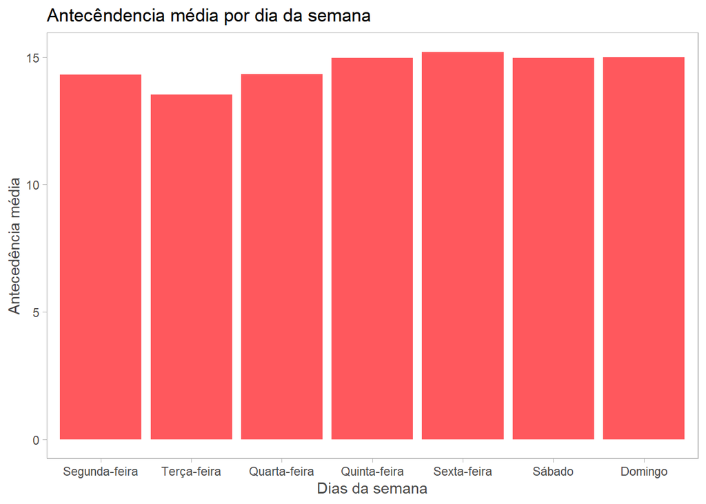

```r
# Visualizando a diferenca media por dias da semana
ggplot(weekday, aes(x=weekday,y=media))+
  geom_col(fill="#FF585D")+
  labs(x = "Dias da semana", y = "Antecedência média",
       title = "Antecêndencia média por dia da semana")+
  theme_light()+
  theme(panel.grid = element_blank(),
        axis.title = element_text(colour = "#484848"))
```

# NOTAS FINAIS SOBRE O DESAFIO

Achei essa experiência muito interessante! O desafio propôs uma situação real e pediu soluções práticas, plausíveis e desafiadoras o suficiente. Me permitiu a liberdade de entregar o resultado de diversas formas, seja utilizando o R ou Python, fazendo um notebook Jupyter ou entregando simplesmente em PDF. O tempo de entrega do desafio foi justo.

Além das soluções pedidas, achei interessante entregar um produto a mais para essa análise. Desenvolvi um aplicativo web que funciona como um dashboard online para visualização rápida dos dados, nesse aplicativo é possível encontrar gráficos de variáveis individuais, gráficos de cruzamento de variáveis e gráficos de variáveis ao longo do tempo. O aplicativo pode ser encontrado nesse [link](https://wesley-almeida-cruz-wess.shinyapps.io/desafio_seazone/).

Finalmente, meu *feedback* para o desafio proposto pela Seazone é extremamente positivo!